# Rによる二次分析入門: 事前課題

セミナー当日までに確認していただきたいこと

作者

藤原翔（東京大学）

公開

2026年2月15日

# 1 はじめに

本資料は「Rによる二次分析入門」セミナーの事前課題です。当日スムーズに分析に入れるよう、以下の準備をセミナー前日までに完了してください。

**所要時間の目安**: 1〜2時間（ダウンロード時間を除く）

**準備ができない場合**

インストールやデータの準備でうまくいかない場合は、事前にメール（sho.fujihara@iss.u-tokyo.ac.jp）でご連絡ください。当日の開始前にサポートします。

# 2 R・RStudioのインストール

[video not shown]

**R**は統計分析のためのプログラミング言語、**RStudio**はRを便利に使うための編集環境（エディタ）です。両方をインストールし、普段の作業ではRStudioを起動してRを使います。

## 2.1 Rのインストール

1. [CRAN](https://cran.r-project.org/) にアクセス
2. 自分のOSに合ったリンクをクリック
   - **Windows**: 「Download R for Windows」→「base」→「Download R-4.x.x for Windows」をクリック
   - **Mac**: 「Download R for macOS」→ 以下のいずれかを選択
     - **Apple Silicon（M1〜M4）Mac**の場合: `arm64` と書かれた `.pkg` ファイル
     - **Intel Mac**の場合: `x86_64` と書かれた `.pkg` ファイル
3. ダウンロードしたファイルを実行してインストール（設定はすべてデフォルトのままでOK）

**自分のMacの種類を確認する方法**

画面左上のリンゴマーク →「このMacについて」→「チップ」の項目を確認してください。「Apple M1」「Apple M2」などと表示されればApple Silicon、「Intel」と表示されればIntel Macです。

## 2.2 RStudioのインストール

1. [Posit社のダウンロードページ](https://posit.co/download/rstudio-desktop/) にアクセス
2. 「RStudio Desktop Free」の「Download」をクリック
3. 自分のOSに合ったインストーラをダウンロードして実行

**インストール時のセキュリティ警告**

- **Windows**: 「WindowsによってPCが保護されました」と表示された場合 →「詳細情報」→「実行」をクリックしてください
- **Mac**: 「開発元を確認できないため開けません」と表示された場合 → アプリを右クリック（またはControl+クリック）→「開く」を選択してください。それでも開けない場合は「システム設定」→「プライバシーとセキュリティ」から実行を許可してください

## 2.3 RStudioの起動確認

RStudioを起動すると 図 1 のような画面が表示されます。

[figure not shown]

図 1: RStudioの画面

画面には4つの領域（pane）があります。

- **左上（Source）**: スクリプトを編集する場所
- **左下（Console）**: 結果が表示される場所
- **右上（Environment）**: 作成したオブジェクトを確認する場所
- **右下（Output）**: ファイル、図、ヘルプなどが表示される場所

**Paneの配置変更**

図 2 の赤枠部分からPaneの配置を変更できます。「Console on Right」を選択すると、コンソールが右上に移動します。好みに応じて設定してください。

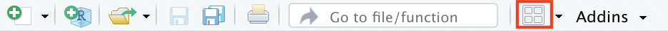

図 2: Paneの設定

# 3 プロジェクトの作成

[video not shown]

RStudioでは**プロジェクト**を使ってファイルを管理します。プロジェクトを開くと、Rの**作業ディレクトリ**（Rがファイルを探したり保存したりする場所）が自動的にそのフォルダに設定されます。これにより、ファイルのパスを毎回指定する手間がなくなり、分析の管理が楽になります。

**作業ディレクトリの確認**

現在の作業ディレクトリは `getwd()` で確認できます。プロジェクトを開いた状態で実行すると、プロジェクトフォルダのパスが表示されます。

```r
getwd()
```

## 3.1 新規プロジェクトの作成

1. RStudioのメニューから「File」→「New Project…」を選択
2. 「New Directory」を選択
3. 「New Project」を選択
4. 以下を設定
   - **Directory name**: `benesse_seminar`（プロジェクト名）
   - **Create project as subdirectory of**: 保存先を選択（デスクトップやDocumentsなど分かりやすい場所）
5. 「Create Project」をクリック

**すでにフォルダを作成済みの場合**

上の動画のように、先にフォルダを作成してある場合は、手順2で「New Directory」ではなく「**Existing Directory**」を選択し、作成済みのフォルダを指定してください。

**フォルダのパスに日本語を含めない**

保存先のパスに日本語が含まれると、ファイルの読み込みでエラーが起きることがあります。例えば `C:/Users/藤原/デスクトップ/benesse_seminar` のようなパスは避け、`C:/Users/fujihara/Desktop/benesse_seminar` のように英数字のパスを選んでください。

## 3.2 フォルダ構成の作成

プロジェクトフォルダ内に、以下のフォルダを作成してください。

```
benesse_seminar/
├── benesse_seminar.Rproj
├── data/
│   ├── raw/          # 元データ
│   │   ├── 1571/     # メインのパネルデータ
│   │   ├── 1577/     # 2016年度語彙力・読解力調査
│   │   └── 1578/     # 2019年度語彙力・読解力調査
│   └── processed/    # 加工済みデータ
├── scripts/          # Rスクリプト
├── figures/          # 図
└── tables/           # 表
```

RStudioの右下ペインの「Files」タブから「New Folder」でフォルダを作成できます。

あるいは、以下のRコードを実行してフォルダを一括作成することもできます。ただし、**プロジェクトを開いた状態**（作業ディレクトリがプロジェクトフォルダに設定されている状態）で実行してください。`getwd()` でプロジェクトフォルダのパスが表示されることを確認してから実行すると安全です。

```r
# フォルダを作成
dir.create("data/raw/1571", recursive = TRUE)
dir.create("data/raw/1577", recursive = TRUE)
dir.create("data/raw/1578", recursive = TRUE)
dir.create("data/processed", recursive = TRUE)
dir.create("scripts", recursive = TRUE)
dir.create("figures", recursive = TRUE)
dir.create("tables", recursive = TRUE)
```

# 4 パッケージのインストール

[video not shown]

Rでは「パッケージ」を追加することで機能を拡張できます。セミナーで使用するパッケージを事前にインストールしてください。

**`install.packages()` と `library()` の違い**

パッケージの利用には2つのステップがあります。

- **`install.packages()`**: パッケージをパソコンにダウンロード・保存する（**初回のみ**）
- **`library()`**: インストール済みのパッケージをRに読み込む（**Rを起動するたびに必要**）

スマートフォンのアプリに例えると、`install.packages()` はアプリのインストール、`library()` はアプリを開く操作に相当します。

なお、Rを**メジャーアップデート**（例: 4.3 → 4.4）した場合はパッケージの再インストールが必要になることがあります（RStudioのアップデートでは不要です）。

以下のコードをRStudioのコンソールに貼り付けて実行してください。

```r
# 必要なパッケージのインストール
install.packages(c(
  "tidyverse",    # データ操作・可視化（dplyr, ggplot2など）
  "haven",        # Stata/SPSSファイルの読み込み
  "here",         # ファイルパスの管理
  "janitor",      # データクリーニング
  "modelsummary", # 回帰分析の結果表示
  "fixest",       # 固定効果モデル
  "marginaleffects", # 限界効果の計算
  "broom",        # モデル結果の整形
  "ggalluvial",   # Sankey図
  "scales"        # 軸ラベルの書式設定
))
```

**インストール中の赤いメッセージ**

インストール中にコンソールに赤い文字でメッセージが大量に表示されますが、**これはエラーではありません**。パッケージのダウンロード・コンパイルの進捗状況を示すもので、正常な動作です。初めてのインストールでは数分〜10分程度かかることがあります。「パッケージをソースからインストールしますか？」と聞かれたら「No」を選択してください。

**`library()` 実行時のメッセージ**

`library(tidyverse)` を実行すると、含まれるパッケージの一覧や「Conflicts」（関数名の競合）といったメッセージが表示されますが、これも正常です。エラーが出なければ問題ありません。

インストールが完了したら、以下のコードでパッケージが正しく読み込めるか確認してください。

```r
# パッケージの読み込みテスト
library(tidyverse)
library(haven)
library(here)
```

エラーが出なければ成功です。

# 5 データのダウンロードと配置

## 5.1 データの入手

セミナーで使用するデータは、東京大学社会科学研究所附属社会調査・データアーカイブ研究センター（CSRDA）のSSJDAが提供するものです。

**データ利用について**

本セミナーのみでの利用の場合は、個人での申請は必要ありません。セミナー用にデータを配布します。

ただし、本セミナーを発展させて研究として分析し発表したい場合は、SSJDAへの個人での申請をお願いします。

- [SSJDAウェブサイト](https://csrda.iss.u-tokyo.ac.jp/)

ダウンロードするデータは以下の3つです。

1. **1571**: 子どもの生活と学びに関する親子調査（メインのパネルデータ）
2. **1577**: 2016年度語彙力・読解力調査
3. **1578**: 2019年度語彙力・読解力調査

## 5.2 データの配置

ダウンロードしたzipファイルを展開し、以下のように配置してください（Windowsの場合はzipファイルを右クリック →「すべて展開」、Macの場合はダブルクリックで展開できます）。

- `1571.dta`（または`1571.csv`）→ `data/raw/1571/` フォルダ内
- `1577.dta`（または`1577.csv`）→ `data/raw/1577/` フォルダ内
- `1578.dta`（または`1578.csv`）→ `data/raw/1578/` フォルダ内

最終的なフォルダ構造は以下のようになります。

```
benesse_seminar/
└── data/
    └── raw/
        ├── 1571/
        │   ├── 1571.csv
        │   ├── 1571.dta
        │   ├── 1571.label.txt
        │   ├── 1571.sav
        │   ├── 1571_readme.txt
        │   ├── 親子パネル調査w1-7公表実施状況.xlsx
        │   └── 親子調査項目対照表_w1-7.xlsx
        ├── 1577/
        │   ├── 1577.csv
        │   ├── 1577.dta
        │   ├── 1577.sav
        │   ├── 1577_label.txt
        │   └── 1577_readme.txt
        └── 1578/
            ├── 1578.csv
            ├── 1578.dta
            ├── 1578.sav
            ├── 1578_label.txt
            └── 1578_readme.txt
```

**.dtaファイルの使用を推奨**

`.dta`（Stata形式）ファイルには、メタデータ（変数の意味を示す変数ラベルや、数値に対応するカテゴリ名を示す値ラベルなど）が含まれているため、こちらの使用を推奨します。`.csv`ファイルにはこれらのメタデータが含まれていません。

ただし、データに付属するメタデータだけを鵜呑みにせず、調査票やコードブック、単純集計表を確認することも重要です。

# 6 データ読み込みの確認

[video not shown]

データが正しく配置できたか確認します。以下のコードを実行してください。

```r
# パッケージの読み込み
library(tidyverse)
library(haven)
library(here)

# データの読み込み
# here() はプロジェクトフォルダを基準にパスを組み立てる関数
d <- haven::read_dta(here("data", "raw", "1571", "1571.dta"))

# データの確認
glimpse(d)
```

以下のように、データの行数・列数と各変数の名前・型・最初の数値が表示されれば成功です。

[output not shown]

**データの中身を見る**

読み込んだデータの特定の変数（列）にアクセスするには、`$` を使います。また、`[行, 列]` の形式で特定の行や列を取り出すこともできます。

```r
# PanelID列を表示
d$PanelID

# 特定の変数の度数分布を確認
table(d$w1学年)

# 最初の5行、3〜4列目を表示
d[1:5, 3:4]
```

**CSVファイルを使う場合**

`.dta` ではなく `.csv` ファイルを使う場合は、`read_csv()` で読み込みます。

```r
d <- readr::read_csv(here("data", "raw", "1571", "1571.csv"))
```

## 6.1 読み込みがうまくいかない場合

### 6.1.1 ファイルが見つからないエラー

```
Error: 'data/raw/1571/1571.dta' does not exist.
```

→ ファイルのパスが間違っている可能性があります。以下を確認してください。

- プロジェクトフォルダの直下に`data`フォルダがあるか
- `data/raw/1571/`フォルダ内に`1571.dta`ファイルがあるか

### 6.1.2 Import Datasetを使う方法

コードでの読み込みがうまくいかない場合は、RStudioのメニューから読み込む方法もあります。

**Code Previewを活用する**

Import Datasetの画面右下に表示される「Code Preview」には、読み込みに使われるRコードが表示されています。このコードをコピーしてスクリプトに貼り付けておけば、次回以降はメニューを使わずにコードから同じデータを読み込めます。

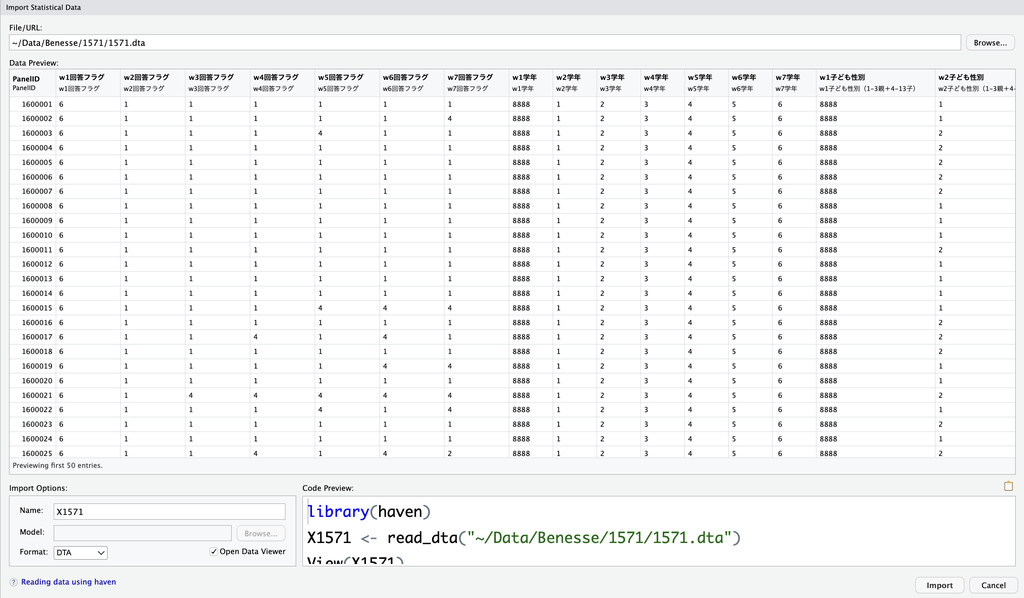

図 3: Import Dataset（haven）の画面例

# 7 Rの基本操作（任意）

[video not shown]

時間があれば、以下の基本操作もぜひ試してみてください。セミナー当日の理解がスムーズになります。これらはセミナー本体の資料でも改めて説明しますので、ここでは雰囲気をつかむ程度で大丈夫です。

## 7.1 スクリプトの作成

図 4 の赤枠部分からRスクリプトを新規作成できます。

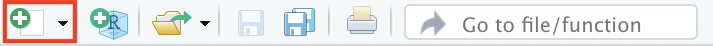

図 4: スクリプトを開く

## 7.2 コメント

`#`（ハッシュ）より右側の文字はRに無視されます。コードの説明や覚え書きとして活用してください。

```r
# これはコメントです（実行されません）
1 + 1  # 行の途中からコメントを書くこともできます
```

```
[1] 2
```

## 7.3 スクリプトの実行方法

スクリプトにコードを入力したら、以下のいずれかの方法で実行します。

### 7.3.1 1行ずつ実行（最もよく使う）

カーソルがある行を実行し、自動的に次の行に移動します。

- **キーボード**: `Ctrl + Enter`（Macは `Cmd + Enter`）
- **ボタン**: スクリプトペイン右上の「Run」ボタン

**複数行をまとめて実行**

実行したい範囲をマウスで選択してから `Ctrl + Enter`（Macは `Cmd + Enter`）を押すと、選択した部分だけをまとめて実行できます。

### 7.3.2 スクリプト全体を実行

スクリプトの全行を一括で実行します。

- **キーボード**: `Ctrl + Shift + Enter`（Macは `Cmd + Shift + Enter`）
- **ボタン**: スクリプトペイン右上の「Source」ボタン
- **コード**: `source("scripts/my_script.R")`

**RunとSourceの違い**

「Run」はカーソル位置の1行（または選択範囲）を実行します。「Source」はスクリプト全体を最初から最後まで実行します。データの読み込みから分析まで一連の処理をまとめて再実行したいときに「Source」が便利です。

### 7.3.3 実行してみる

以下のコードをスクリプトに入力し、1行ずつ実行してみてください。

```r
# 足し算
1 + 1
```

```
[1] 2
```

```r
# 掛け算
7 * 8
```

```
[1] 56
```

```r
# 平方根
sqrt(16)
```

```
[1] 4
```

## 7.4 オブジェクトへの代入

Rでは、値や計算結果に名前をつけて保存できます。この「名前をつけた入れ物」を**オブジェクト**と呼びます。`<-`（代入演算子）を使って、右側の値を左側の名前に代入します。

```r
# xに10を代入
x <- 10
x
```

```
[1] 10
```

```r
# ベクトル（複数の値）を代入
y <- c(1, 2, 3, 4, 5)
y
```

```
[1] 1 2 3 4 5
```

## 7.5 ベクトルの作成

`c()` 以外にも、ベクトルを作る便利な方法があります。

```r
# 連続する整数（1から10まで）
1:10
```

```
 [1]  1  2  3  4  5  6  7  8  9 10
```

```r
# 等間隔の数列（0から1まで0.2刻み）
seq(0, 1, by = 0.2)
```

```
[1] 0.0 0.2 0.4 0.6 0.8 1.0
```

```r
# 同じ値の繰り返し（0を5回）
rep(0, 5)
```

```
[1] 0 0 0 0 0
```

## 7.6 ベクトルの計算

ベクトル同士で計算すると、対応する要素ごとに演算されます。

```r
a <- c(1, 2, 3)
b <- c(10, 20, 30)

a + b   # 要素ごとの足し算
```

```
[1] 11 22 33
```

```r
a * b   # 要素ごとの掛け算
```

```
[1] 10 40 90
```

## 7.7 よく使う関数

```r
y <- c(3, 1, 4, 1, 5, 9, 2, 6)

sum(y)      # 合計
```

```
[1] 31
```

```r
length(y)   # 要素数
```

```
[1] 8
```

```r
mean(y)     # 平均
```

```
[1] 3.875
```

```r
median(y)   # 中央値
```

```
[1] 3.5
```

```r
sd(y)       # 標準偏差
```

```
[1] 2.748376
```

**オブジェクトの確認**

作成したオブジェクトは、RStudio右上の「Environment」ペインで確認できます。オブジェクト名を入力して実行すると、その中身が表示されます。

**ヘルプの使い方**

関数の使い方がわからないときは、`?関数名` で右下ペインにヘルプが表示されます。

```r
?mean
?sqrt
```

**オブジェクトを活用するメリット**

オブジェクトを活用することで、効率的な分析が可能になります。

- **再利用**: 一度読み込んだデータや計算結果を何度でも使える
- **可読性**: `mean(income)`のように、何を計算しているか分かりやすくなる
- **修正が容易**: データの前処理を修正しても、後続の分析コードを変更する必要がない
- **再現性**: スクリプトを実行すれば、同じ結果を何度でも再現できる

# 8 チェックリスト

セミナー当日までに、以下が完了していることを確認してください。

- R・RStudioがインストールされている（→ 第2章）
- RStudioが正常に起動する（→ 第2.3節）
- `benesse_seminar`プロジェクトが作成されている（→ 第3章）
- フォルダ構成（data/raw, data/processed, scripts, figures, tables）が作成されている（→ 第3.2節、難しければセミナー当日に一緒に作成します）
- 必要なパッケージがインストールされている（→ 第4章）
- `library(tidyverse)` がエラーなく実行できる
- データファイルが正しい場所に配置されている（→ 第5章）
- データの読み込みが成功する（→ 第6章）

すべてにチェックがついたら準備完了です。当日お会いできることを楽しみにしています。

# 9 困ったときは

## 9.1 よくあるエラーと対処法

### 9.1.1 パッケージのインストールでエラーが出る

```r
# CRANのミラーを明示的に指定してみる
install.packages("tidyverse", repos = "https://cran.rstudio.com/")
```

### 9.1.2 日本語のファイルパスで問題が起きる

プロジェクトの保存先を変更してください（→「プロジェクトの作成」の注意を参照）。

## 9.2 参考動画

Rの基礎についてさらに学びたい方は、以下の動画も参考にしてください。

- [自分で関数を作る](https://youtu.be/dhHGNr-3qdA)（3:46）
- [変数からデータを作成する方法](https://youtu.be/kNx_Mjv8FGI)（5:35）
- [パイプ演算子](https://youtu.be/L5dac9sXm3c)（25:20）
- [Posit Cloud（旧RStudio Cloud）の設定](https://youtu.be/JDC1sY_bouA)（8:27）

## 9.3 参考リンク

- [R公式サイト](https://www.r-project.org/)
- [RStudio公式サイト](https://posit.co/products/open-source/rstudio/)
- [R for Data Science（英語・無料）](https://r4ds.hadley.nz/)
- [私たちのR:ベストプラクティスの探究（日本語・無料）](https://www.jaysong.net/RBook/)